# Logistic Regression

GLMs for proportions

Philip Leftwich

University of East Anglia

2026-02-19

# Introduction

## Learning Objectives

By the end of this session, you will be able to:

1. Fit appropriate models to proportional data
2. Evaluate models for best fit
3. Deliver transparent and clear reporting

# Recap

## What have you learned so far?

- What are the assumptions of the ordinary linear model?
- Tell me one thing you don’t quite understand about GLMs?

# Binary outcomes

## GLMS for binary data

Common response variable in ecological datasets is the binary variable: we observe a phenomenon X or its “absence”

- Presence/Absence of a species
- Presence/Absence of a disease
- Success/Failure to observe behaviour
- Survival/Death of organisms

Wish to determine if $P(event)∼ Variable$

Linear regression is inappropriate because probabilities are bounded between 0 and 1

## Binary example: Mayflies

- Investigating mayfly abundance in relation to pollution gradient measured in Cumulative Criterion Units (CCU)
- Mayflies serve as indicators of stream health due to sensitivity to metal pollution
- Higher CCU values indicate increased metal pollution, potentially impacting mayfly presence or absence in the stream

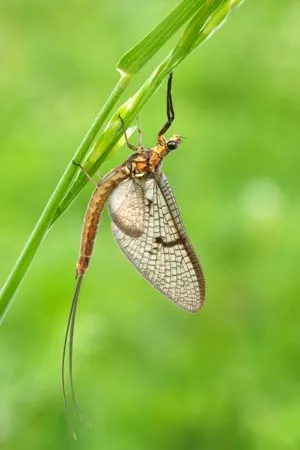

## Example: Mayflies

Fitting a linear regression vs a logit-link regression:

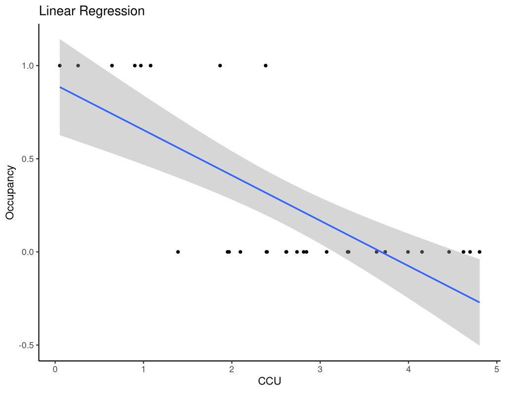

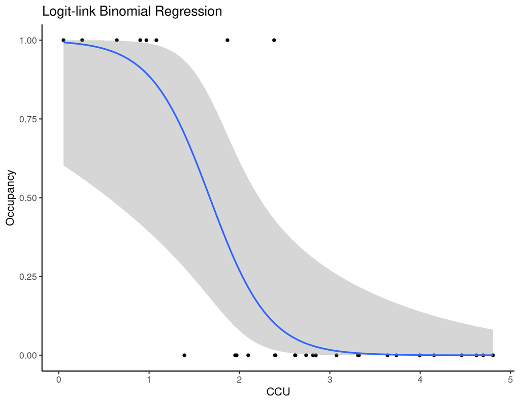

## Probability, odds, logit-odds

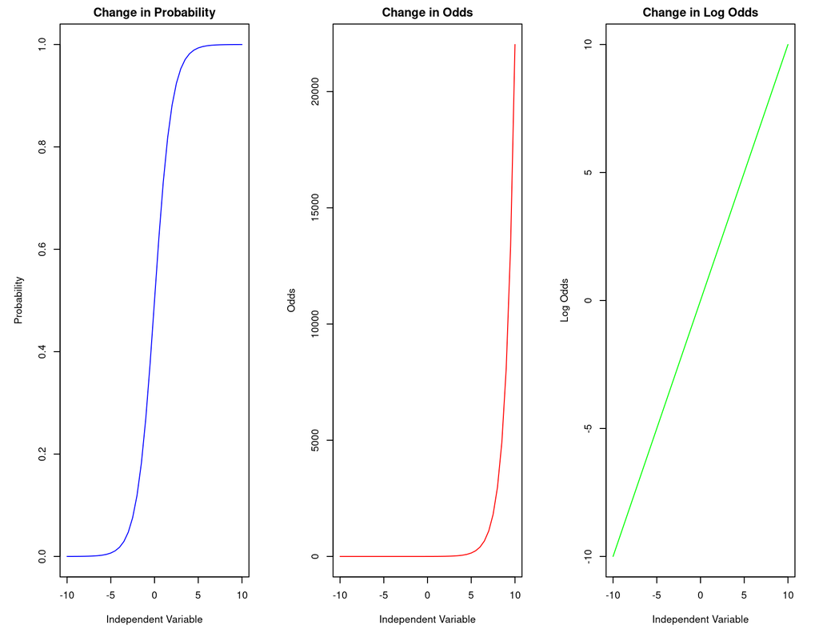

- The odds put our expected values on a 0 to +Inf scale.
- The log transformation puts our expected values on a -Inf to +Inf scale.
- Now, the expected values can be linearly related to the linear predictor.

## Fitting the model

```r
mayfly_glm <- glm(Occupancy ~ CCU,
                  family = binomial(link = "logit"),
                  data = Mayflies)

summary(mayfly_glm)
```

```
Call:
glm(formula = Occupancy ~ CCU, family = binomial(link = "logit"),
    data = Mayflies)

Coefficients:
            Estimate Std. Error z value Pr(>|z|)
(Intercept)    5.102      2.369   2.154   0.0313 *
CCU           -3.051      1.211  -2.520   0.0117 *
---
Signif. codes:  0 '***' 0.001 '**' 0.01 '*' 0.05 '.' 0.1 ' ' 1

(Dispersion parameter for binomial family taken to be 1)

    Null deviance: 34.795  on 29  degrees of freedom
Residual deviance: 12.649  on 28  degrees of freedom
AIC: 16.649

Number of Fisher Scoring iterations: 7
```

- Coefficients represent changes in log-odds.

## Interpret the model

```
Call:
glm(formula = Occupancy ~ CCU, family = binomial(link = "logit"),
    data = Mayflies)

Coefficients:
            Estimate Std. Error z value Pr(>|z|)
(Intercept)    5.102      2.369   2.154   0.0313 *
CCU           -3.051      1.211  -2.520   0.0117 *
---
Signif. codes:  0 '***' 0.001 '**' 0.01 '*' 0.05 '.' 0.1 ' ' 1

(Dispersion parameter for binomial family taken to be 1)

    Null deviance: 34.795  on 29  degrees of freedom
Residual deviance: 12.649  on 28  degrees of freedom
AIC: 16.649

Number of Fisher Scoring iterations: 7
```

Each coefficient corresponds to a predictor variable, indicating the change in the **log odds** of the response variable associated with a one-unit change in that predictor, holding other predictors constant.

- Interpretation of coefficients involves exponentiating them to obtain odds ratios.
- An odds ratio greater than 1 implies higher odds of the event occurring with an increase in the predictor.
- An odds ratio less than 1 implies lower odds of the event occurring with an increase in the predictor.

## Exponentiating

```r
broom::tidy(mayfly_glm, exponentiate = T)
```

```
# A tibble: 2 × 5
  term        estimate std.error statistic p.value
  <chr>          <dbl>     <dbl>     <dbl>   <dbl>
1 (Intercept) 164.          2.37      2.15  0.0313
2 CCU           0.0473      1.21     -2.52  0.0117
```

- Exponentiating gives **odds ratios**
- These are multiplicative, while log odds are additive

## Prediction

> How probability of occupancy changes across the pollution gradient.

```r
emmeans::emmeans(mayfly_glm,
                 specs = ~ CCU,
                 at=list(CCU=c(0:5)),
                 type='response') |>
  as_tibble()
```

```
# A tibble: 6 × 6
    CCU      prob       SE    df    asymp.LCL asymp.UCL
  <int>     <dbl>    <dbl> <dbl>        <dbl>     <dbl>
1     0 0.994     0.0142     Inf 0.613           1.00
2     1 0.886     0.129      Inf 0.391           0.990
3     2 0.269     0.147      Inf 0.0780          0.615
4     3 0.0171    0.0263     Inf 0.000816        0.271
5     4 0.000823  0.00221    Inf 0.00000422      0.139
6     5 0.0000390 0.000151   Inf 0.0000000198    0.0714
```

## Prediction plots with emmeans

We can use `emmeans` package to compute estimated marginal means (EMMs) from a fitted GLM, convert them into a tibble format for visualization with ggplot2, overlay the means with uncertainty ribbons and add them on a scatter plot of the original data.

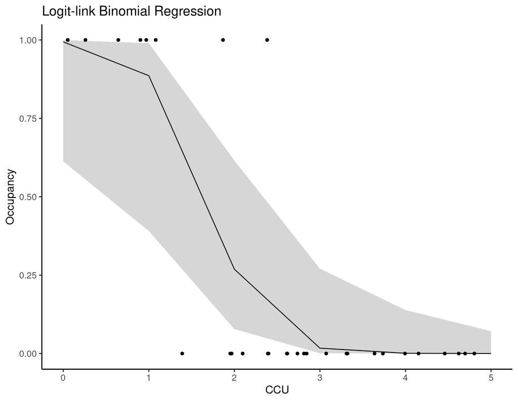

```r
means <- emmeans::emmeans(mayfly_glm,
                 specs = ~ CCU,
                 at=list(CCU=c(0:5)),
                 type='response') |>
  as_tibble()

ggplot(Mayflies, aes(x=CCU, y=Occupancy)) + geom_point()+
    geom_ribbon(data = means,
              aes(x = CCU,
                  y = prob,
                  ymin = asymp.LCL,
                  ymax = asymp.UCL),
              alpha = .2)+
  geom_line(data = means,
            aes(x = CCU,
                y = prob)) +  # regression line
  labs(title = "Logit-link Binomial Regression",
       x = "CCU", y = "Occupancy")+
  theme_classic(base_size = 14)
```

# Binomial Distribution

Binary data = one trial per observation.

Often we observe multiple trials per unit:

Examples:

- Number of seedlings that germinate out of 20 seeds
- Number of insects that die out of 50 exposed individuals
- Number of infected hosts out of a sampled population

This is binomial data.

> The model is the same — only the data structure change

## Binomial distribution

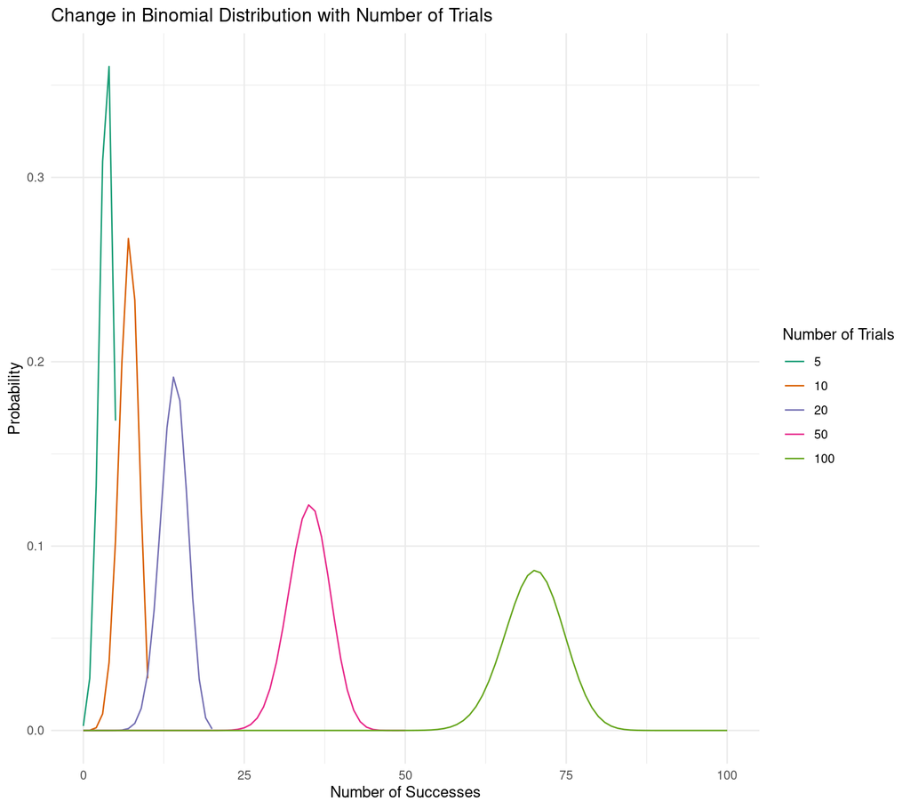

$logit(p) = \log \frac{p}{1 - p}$

$y_i = Binomial(n,p)$

- It is the collection of Bernoulli trials for the same event
- It is represented by the number of Bernoulli trials $n$
- It is also the probability of an event in each trial $p$

## Binomial: Example

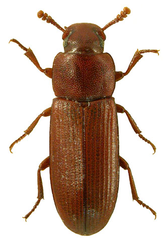

This small dataset is from an experiment looking at mortality in batches of flour exposed to different doses of pesticides.

The question of interest is:

> How does pesticide dose affect mortality in the flour beetle *Tribolium castaneum*

## The data

```
# A tibble: 8 × 4
   Dose Number_tested Number_killed Mortality_rate
  <dbl>         <dbl>         <dbl>          <dbl>
1  49.1            49             6          0.122
2  53.0            60            13          0.217
3  56.9            62            18          0.290
4  60.8            56            28          0.5
5  64.8            63            52          0.825
6  68.7            59            53          0.898
7  72.6            62            61          0.984
8  76.5            60            60          1
```

## Preparing the data

As well as the numbers killed, we need the numbers that remain alive

```r
beetles <- beetles |>
  rename("dead" = Number_killed,
         "trials" = Number_tested) |>
  mutate("alive" = trials-dead)

beetles
```

```
# A tibble: 8 × 5
   Dose trials  dead Mortality_rate alive
  <dbl>  <dbl> <dbl>          <dbl> <dbl>
1  49.1     49     6          0.122    43
2  53.0     60    13          0.217    47
3  56.9     62    18          0.290    44
4  60.8     56    28          0.5      28
5  64.8     63    52          0.825    11
6  68.7     59    53          0.898     6
7  72.6     62    61          0.984     1
8  76.5     60    60          1         0
```

## cbind

The GLM of the binomial counts will analyse the number of *each* batch of beetles killed, while taking into account the size of each group

```r
#cbind() creates a matrix of successes and failures for each batch

beetle_glm <- glm(cbind(dead, alive) ~ Dose, family = binomial(link = "logit"), data = beetles)

summary(beetle_glm)
```

```
Call:
glm(formula = cbind(dead, alive) ~ Dose, family = binomial(link = "logit"),
    data = beetles)

Coefficients:
             Estimate Std. Error z value Pr(>|z|)
(Intercept) -14.57806    1.29846  -11.23   <2e-16 ***
Dose          0.24554    0.02149   11.42   <2e-16 ***
---
Signif. codes:  0 '***' 0.001 '**' 0.01 '*' 0.05 '.' 0.1 ' ' 1

(Dispersion parameter for binomial family taken to be 1)

    Null deviance: 267.6624  on 7  degrees of freedom
Residual deviance:   8.4379  on 6  degrees of freedom
AIC: 38.613

Number of Fisher Scoring iterations: 4
```

## Checking Binomial model fit

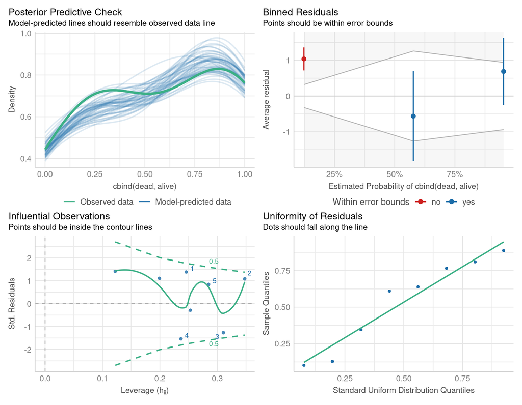

```r
performance::check_model(beetle_glm,
                         detrend = FALSE)
```

## Estimates of significance

Confidence intervals

```r
library(broom)
tidy(beetle_glm, conf.int = T)
```

```
# A tibble: 2 × 7
  term        estimate std.error statistic  p.value conf.low conf.high
  <chr>          <dbl>     <dbl>     <dbl>    <dbl>    <dbl>     <dbl>
1 (Intercept)  -14.6      1.30       -11.2 3.00e-29  -17.3     -12.2
2 Dose           0.246    0.0215      11.4 3.18e-30    0.206     0.290
```

```r
drop1(beetle_glm, test = "Chi")
```

```
Single term deletions

Model:
cbind(dead, alive) ~ Dose
       Df Deviance     AIC    LRT  Pr(>Chi)
<none>       8.438  38.613
Dose    1  267.662 295.837 259.23 < 2.2e-16 ***
---
Signif. codes:  0 '***' 0.001 '**' 0.01 '*' 0.05 '.' 0.1 ' ' 1
```

## Predictions

```r
emmeans::emmeans(beetle_glm,
                 specs = ~ Dose,
                 at=list(Dose=c(40, 50, 60, 70, 80)),
                 type='response')
```

```
 Dose    prob      SE  df asymp.LCL asymp.UCL
   40 0.00852 0.00382 Inf   0.00354    0.0204
   50 0.09103 0.02100 Inf   0.05742    0.1414
   60 0.53851 0.03260 Inf   0.47432    0.6014
   70 0.93149 0.01600 Inf   0.89282    0.9569
   80 0.99373 0.00279 Inf   0.98506    0.9974

Confidence level used: 0.95
Intervals are back-transformed from the logit scale
```

## Predictions plot

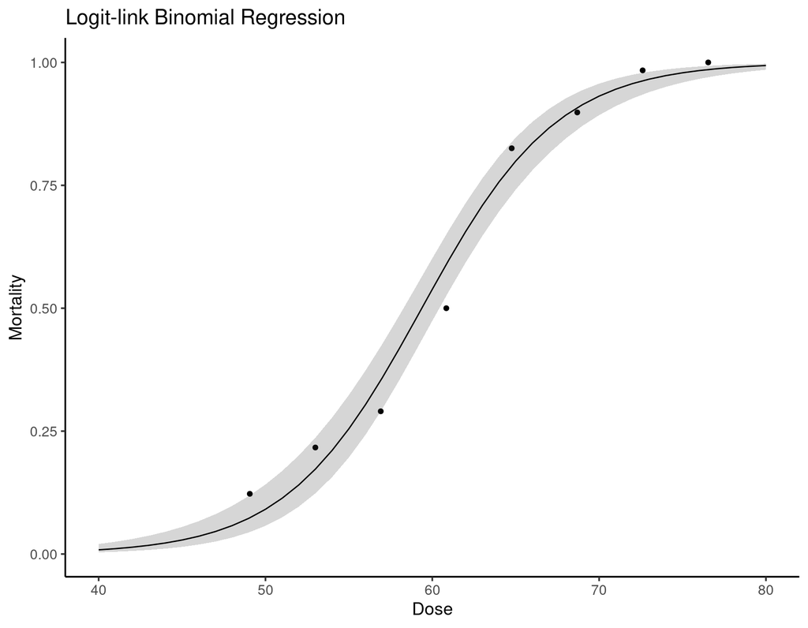

# Overdispersion

## A new issue: Overdispersion

If the **residual deviance of the model is > the residual degrees of freedom** - we consider our binomial models to have **overdispersion**.

This means the variance is greater than predicted by the binomial distribution

$\frac{Residual~Deviance}{Residual~df}$ >1.5 ⇒ Overdispersion

```
Call:
glm(formula = cbind(dead, alive) ~ Dose, family = binomial(link = "logit"),
    data = beetles)

Coefficients:
             Estimate Std. Error z value Pr(>|z|)
(Intercept) -14.57806    1.29846  -11.23   <2e-16 ***
Dose          0.24554    0.02149   11.42   <2e-16 ***
---
Signif. codes:  0 '***' 0.001 '**' 0.01 '*' 0.05 '.' 0.1 ' ' 1

(Dispersion parameter for binomial family taken to be 1)

    Null deviance: 267.6624  on 7  degrees of freedom
Residual deviance:   8.4379  on 6  degrees of freedom
AIC: 38.613

Number of Fisher Scoring iterations: 4
```

## Why overdispersion matters

If overdispersion is present

- Standard errors are too small
- Confidence intervals are too narrow
- p-values are too optimistic

## Overdispersion

**Binomial** $P(X = s) = C(n, s) \cdot p^s \cdot (1 - p)^{n - s}$

**Quasibinomial** $P(X = s) = C(n, s) \cdot p(p+k\theta)^{s-1} \cdot (1 - pk\theta)^{n - s}$

Where:

- $n$ is the total number of trials of an event.
- $s$ corresponds to the number of times an event should occur.
- $p$ is the probability that the event will occur.
- $(1 - p)$ is the probability that the event will not occur.
- $C$ term represents combinations, calculated as $C(n, s) = \frac{n!}{s!(n - s)!}$, representing the number of ways to choose $s$ successes out of $n$ trials.
- $\theta$ term describes additional variance outside of the Binomial distribution

## Fitting the quasibinomial model

```
Call:
glm(formula = cbind(dead, alive) ~ Dose, family = binomial(link = "logit"),
    data = beetles)

Coefficients:
             Estimate Std. Error z value Pr(>|z|)
(Intercept) -14.57806    1.29846  -11.23   <2e-16 ***
Dose          0.24554    0.02149   11.42   <2e-16 ***
---
Signif. codes:  0 '***' 0.001 '**' 0.01 '*' 0.05 '.' 0.1 ' ' 1

(Dispersion parameter for binomial family taken to be 1)

    Null deviance: 267.6624  on 7  degrees of freedom
Residual deviance:   8.4379  on 6  degrees of freedom
AIC: 38.613

Number of Fisher Scoring iterations: 4
```

```
Call:
glm(formula = cbind(dead, alive) ~ Dose, family = quasibinomial(link = "logit"),
    data = beetles)

Coefficients:
             Estimate Std. Error t value Pr(>|t|)
(Intercept) -14.57806    1.46611  -9.943 5.98e-05 ***
Dose          0.24554    0.02427  10.118 5.42e-05 ***
---
Signif. codes:  0 '***' 0.001 '**' 0.01 '*' 0.05 '.' 0.1 ' ' 1

(Dispersion parameter for quasibinomial family taken to be 1.274895)

    Null deviance: 267.6624  on 7  degrees of freedom
Residual deviance:   8.4379  on 6  degrees of freedom
AIC: NA

Number of Fisher Scoring iterations: 4
```

## Fitting the quasibinomial model

Standard Error, Confidence intervals and p-values WILL change.

Estimates remain the same

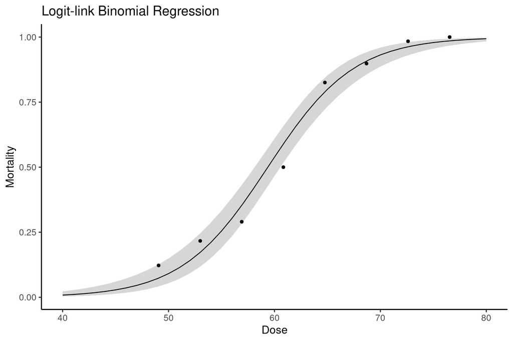

Likelihood ratio tests should now be applied with an F-statistics

```r
drop1(beetle_quasiglm, test = "F")
```

```
Single term deletions

Model:
cbind(dead, alive) ~ Dose
       Df Deviance F value    Pr(>F)
<none>       8.438
Dose    1  267.662  184.33 9.908e-06 ***
---
Signif. codes:  0 '***' 0.001 '**' 0.01 '*' 0.05 '.' 0.1 ' ' 1
```

# What next?

## Model limitations

## Write-ups

## Tables

```r
sjPlot::tab_model(beetle_quasiglm)
```

|  | cbind(dead,alive) |  |  |
| --- | --- | --- | --- |
| Predictors | Odds Ratios | CI | p |
| (Intercept) | 0.00 | 0.00 – 0.00 | **<0.001** |
| Dose | 1.28 | 1.22 – 1.34 | **<0.001** |
| Observations | 8 |  |  |